# Boxplot

Sanghoo Yoon

# Boxplot (상자그림 그리기)

- 기본적인 상자그림을 https://www.statmethods.net/graphs/boxplot.html 을 참고하시기 바랍니다.
- 주의 : 상자그림이 아래의 상자그림을 의미하지 않습니다.

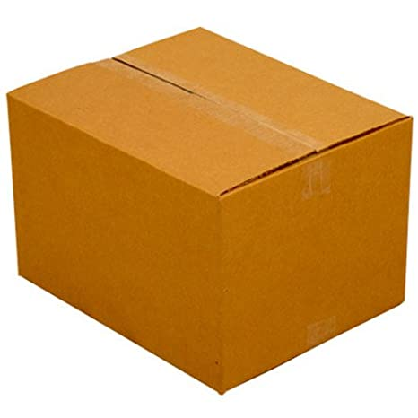

이 그림은 상자입니다. 상자그림이 아니예요

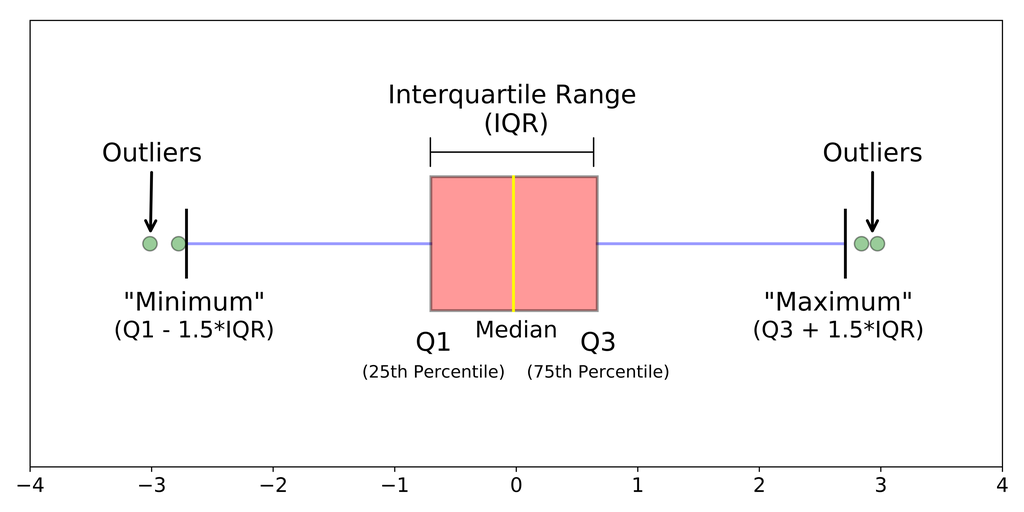

상자그림의 요약값

- 상자그림을 통해 자료의 퍼짐의 정도 즉 분포를 확인할 수 있습니다.
- 많은 수의 자료 분포를 효율적으로 시각화 하는데 전달하는데 그 목적이 있습니다.
- 추가로 *이상치* 여부를 확인할 수 있습니다.

기본적인 상자그림은 다음과 같습니다.

```r
head(mtcars)
```

```
##                    mpg cyl disp  hp drat    wt  qsec vs am gear carb
## Mazda RX4         21.0   6  160 110 3.90 2.620 16.46  0  1    4    4
## Mazda RX4 Wag     21.0   6  160 110 3.90 2.875 17.02  0  1    4    4
## Datsun 710        22.8   4  108  93 3.85 2.320 18.61  1  1    4    1
## Hornet 4 Drive    21.4   6  258 110 3.08 3.215 19.44  1  0    3    1
## Hornet Sportabout 18.7   8  360 175 3.15 3.440 17.02  0  0    3    2
## Valiant           18.1   6  225 105 2.76 3.460 20.22  1  0    3    1
```

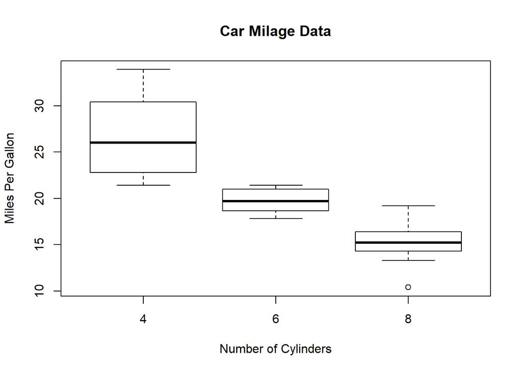

```r
boxplot(mpg~cyl,data=mtcars, main="Car Milage Data",
        xlab="Number of Cylinders", ylab="Miles Per Gallon")
```

- 상자그림은 data.frame으로 되어 있는 자료를 반응치(mpg)를 변수(cyl)별로 확인하고자 할 때 사용됩니다.
- data.frame 아니라 벡터만 있어도 상자그림은 그려집니다.

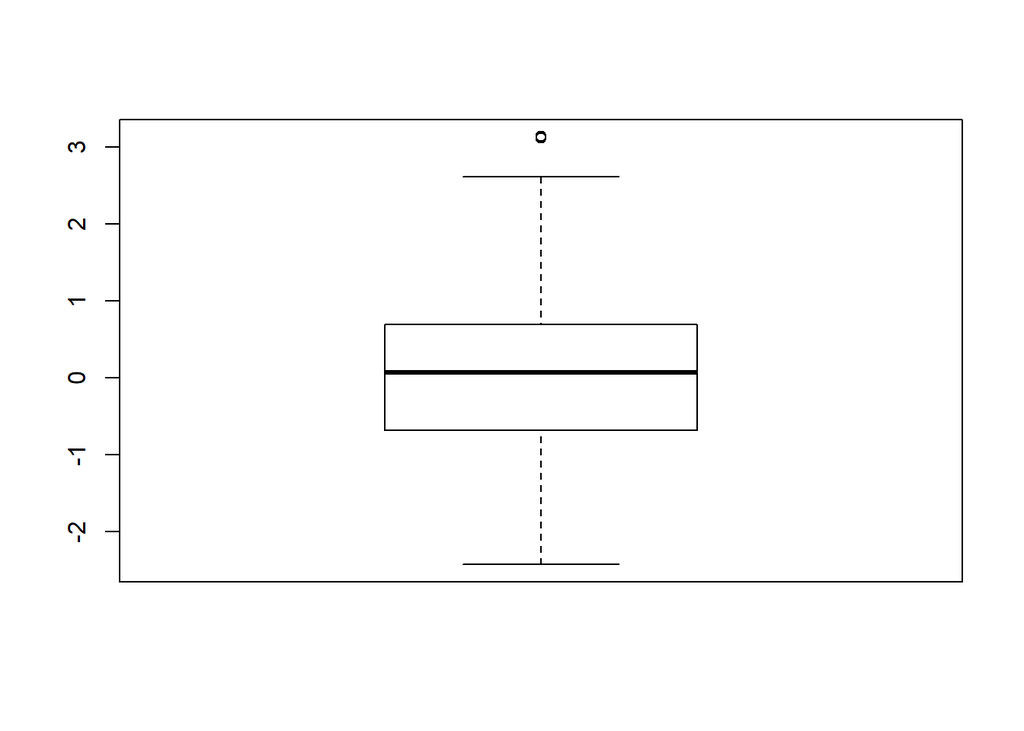

```r
x <- rnorm(100)
boxplot(x)
```

- Norch 라는 옵션을 주게되면 상자의 좌우대칭 여부를 직관적으로 알 수 있습니다.
- 기본적으로 긴 쪽으로 그려지며 안으로 꺽인 경우 비대칭이 발생했다고 볼 수 있습니다.
- 몰론 col 옵션을 통해 원하는 색을 줄 수 있습니다.

```r
head(ToothGrowth)
```

```
##    len supp dose
## 1  4.2   VC  0.5
## 2 11.5   VC  0.5
## 3  7.3   VC  0.5
## 4  5.8   VC  0.5
## 5  6.4   VC  0.5
## 6 10.0   VC  0.5
```

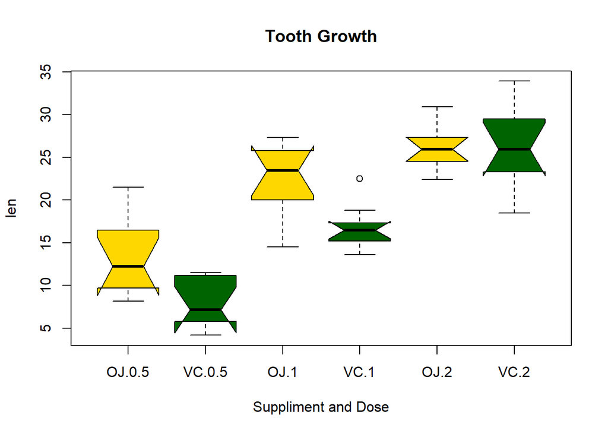

```r
boxplot(len~supp*dose, data=ToothGrowth, notch=TRUE,
        col=(c("gold","darkgreen")),
        main="Tooth Growth", xlab="Suppliment and Dose")
```

- Norch는 자료의 좌우대칭 여부는 제공해주지만 자료의 밀도가 어디에 높은지 알 수 없습니다.
- 자료의 밀도를 좌우로 그려보니 바이올린 모양과 비슷하여 violin plot이 제시되었습니다.

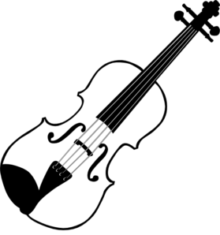

바이올린

바이올린은 올록볼록한 모양의 악기입니다.

- violin plot을 그리기 위해선 *vioplot* 패키지를 설치하여야 합니다.

```r
if(!require(vioplot)) install.packages("vioplot"); library(vioplot)
```

```
## Package 'sm', version 2.2-5.6: type help(sm) for summary information
```

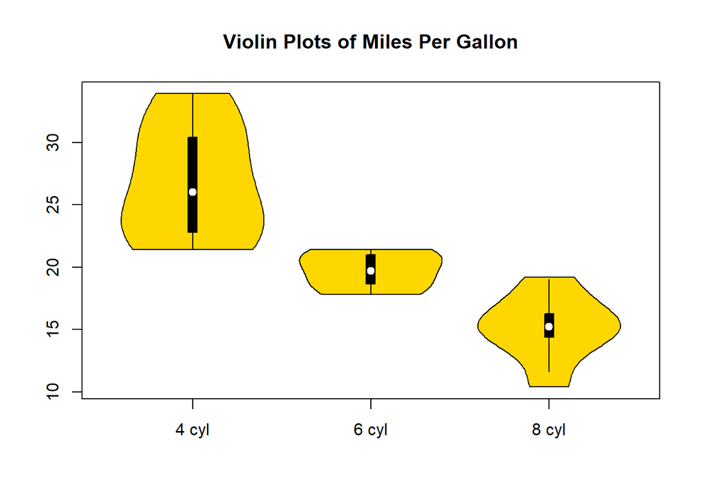

```r
x1 <- mtcars$mpg[mtcars$cyl==4]
x2 <- mtcars$mpg[mtcars$cyl==6]
x3 <- mtcars$mpg[mtcars$cyl==8]
vioplot(x1, x2, x3, names=c("4 cyl", "6 cyl", "8 cyl"), col="gold")
title("Violin Plots of Miles Per Gallon")
```

- 지금까지의 자료의 중심과 퍼짐의 정도는 1차원 시각화 결과 입니다.
- 만약 내가 관심이 있는 두개의 변수에 따른 자료의 퍼짐 정도를 확인한다면???
- 2차원의 상자그림을 그리면 가방과 비슷하다고 하여 Bagplot이라고 합니다.
- Bagplot을 그리기 위해선 *aplpack*을 꼭 설치해주세요.

```r
if(!require(aplpack)) install.packages("aplpack"); library(aplpack)
```

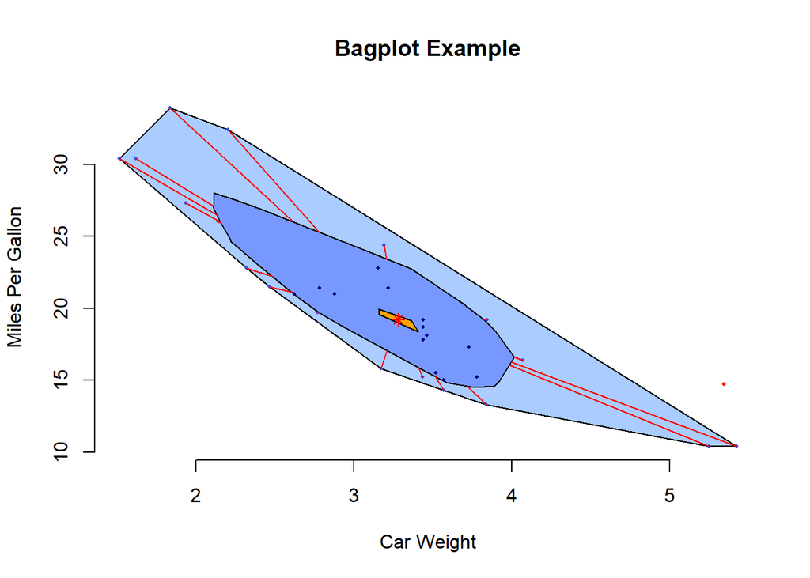

```r
bagplot(mtcars$wt,mtcars$mpg, xlab="Car Weight", ylab="Miles Per Gallon",
        main="Bagplot Example")
```

여기서 부터는 상자그림의 다양한 옵션들에 대해 알아보겠습니다.

### 벡터자료의 시각화

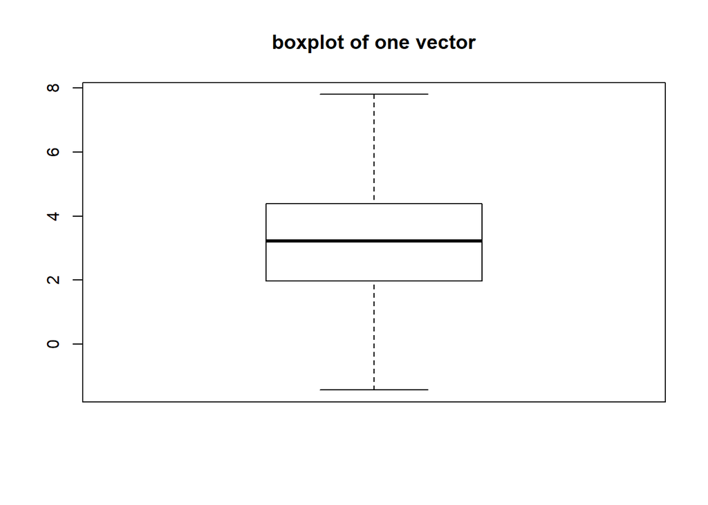

```r
set.seed(1)
norm1 <- round(rnorm(100, 3, 2), digits = 2)
set.seed(2)
norm2 <- round(rnorm(100, 3, 3), digits = 2)

boxplot(norm1, main="boxplot of one vector")
```

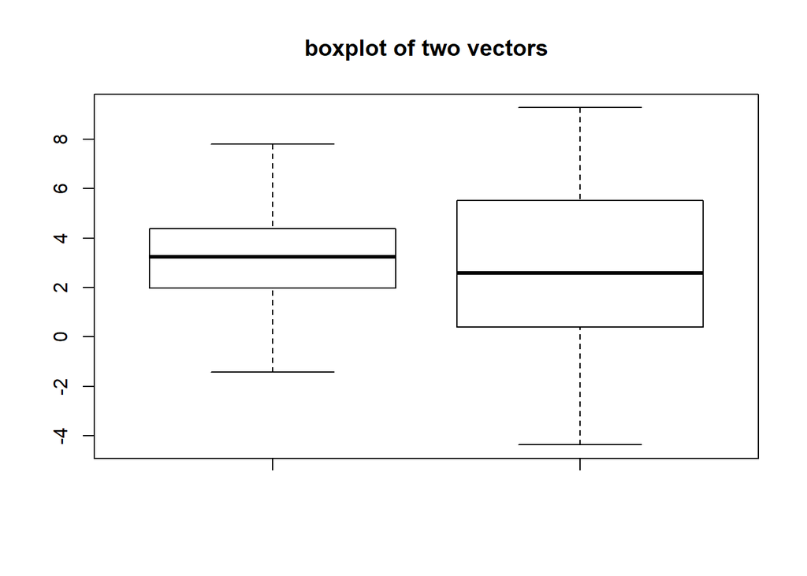

```r
boxplot(norm1, norm2, main="boxplot of two vectors")
```

- 여기서 set.seed는 난수를 생성할 때 동일한 난수가 생성되도록 하는 함수입니다.

### 리스트자료의 시각화

- 리스트로 처리하면 여러개의 벡터를 한꺼번에 처리 할 수 있습니다.

```r
list1 = list(data1 = norm1, data2 = norm2, data3 = rnorm(200, 7, 4))
head(list1)
```

```
## $data1
##   [1]  1.75  3.37  1.33  6.19  3.66  1.36  3.97  4.48  4.15  2.39  6.02  3.78
##  [13]  1.76 -1.43  5.25  2.91  2.97  4.89  4.64  4.19  4.84  4.56  3.15 -0.98
##  [25]  4.24  2.89  2.69  0.06  2.04  3.84  5.72  2.79  3.78  2.89  0.25  2.17
##  [37]  2.21  2.88  5.20  4.53  2.67  2.49  4.39  4.11  1.62  1.59  3.73  4.54
##  [49]  2.78  4.76  3.80  1.78  3.68  0.74  5.87  6.96  2.27  0.91  4.14  2.73
##  [61]  7.80  2.92  4.38  3.06  1.51  3.38 -0.61  5.93  3.31  7.35  3.95  1.58
##  [73]  4.22  1.13  0.49  3.58  2.11  3.00  3.15  1.82  1.86  2.73  5.36 -0.05
##  [85]  4.19  3.67  5.13  2.39  3.74  3.53  1.91  5.42  5.32  4.40  6.17  4.12
##  [97]  0.45  1.85  0.55  2.05
##
## $data2
##   [1]  0.31  3.55  7.76 -0.39  2.76  3.40  5.12  2.28  8.95  2.58  4.25  5.95
##  [13]  1.82 -0.12  8.35 -3.93  5.64  3.11  6.04  4.30  9.27 -0.60  7.77  8.86
##  [25]  3.01 -4.36  4.43  1.21  5.38  3.87  5.22  3.96  6.23  2.15  0.67  1.21
```

[output cut: 42 more lines]

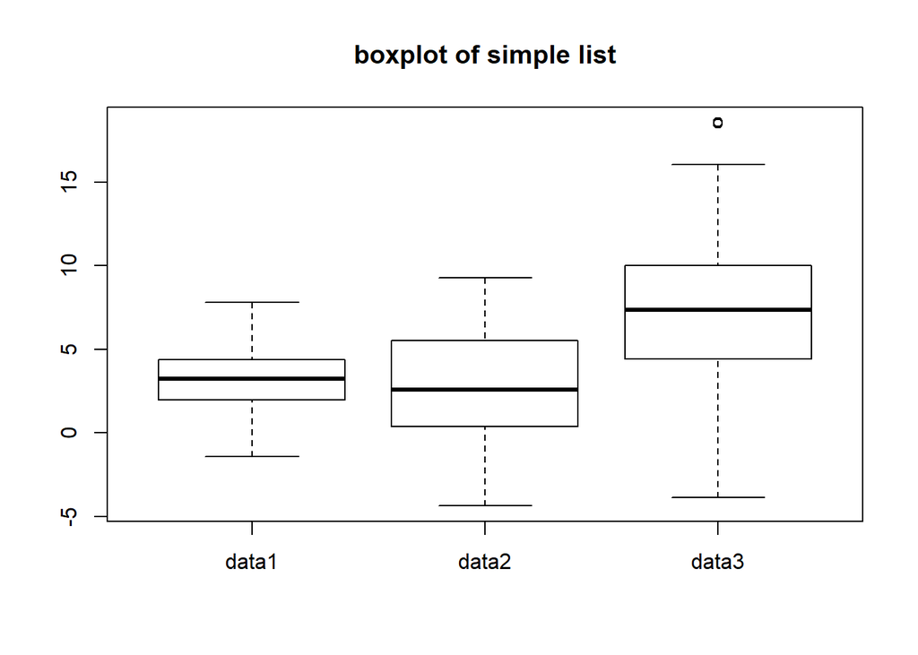

```r
boxplot(list1)
title("boxplot of simple list")
```

### 여러 변수에 따른 상자그림

- 하나변수가 아닌 여러 변수에 따른 상자그림을 그리고 싶다면…
- formula(식)에 +로 변수를 추가하세요.
- subset이나 논리식을 통해 원하는 자료만 선택할 수 있습니다.

```r
head(ToothGrowth)
```

```
##    len supp dose
## 1  4.2   VC  0.5
## 2 11.5   VC  0.5
## 3  7.3   VC  0.5
## 4  5.8   VC  0.5
## 5  6.4   VC  0.5
## 6 10.0   VC  0.5
```

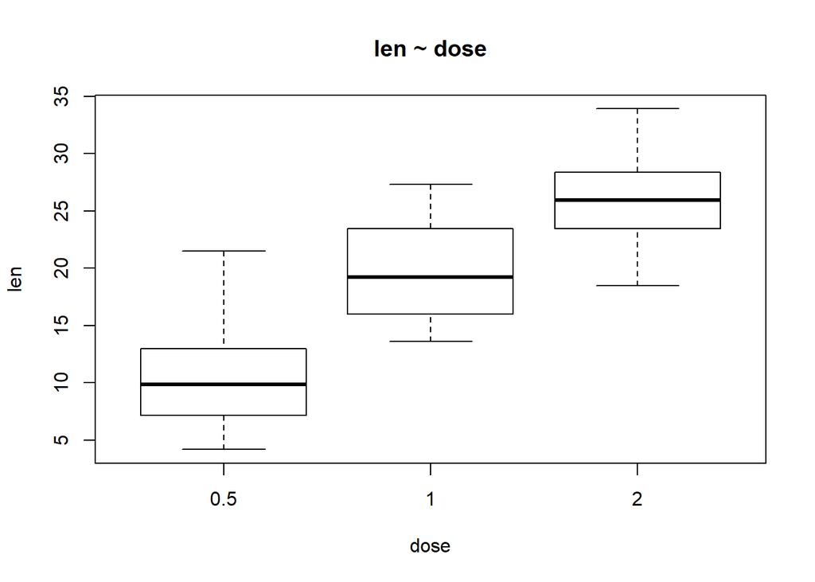

```r
boxplot(len ~ dose, data = ToothGrowth, main="len ~ dose")
```

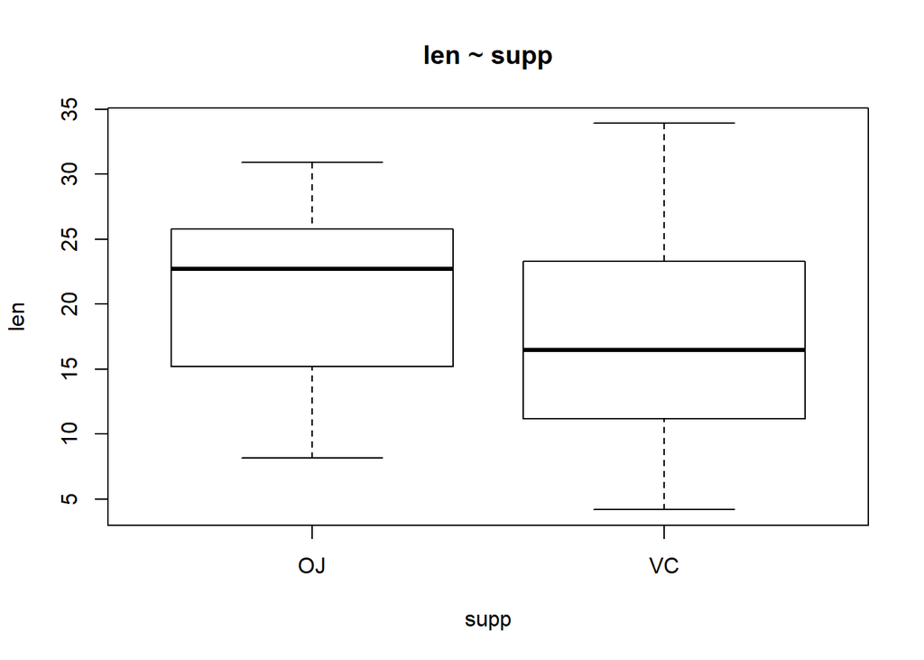

```r
boxplot(len ~ supp, data = ToothGrowth, main="len ~ supp")
```

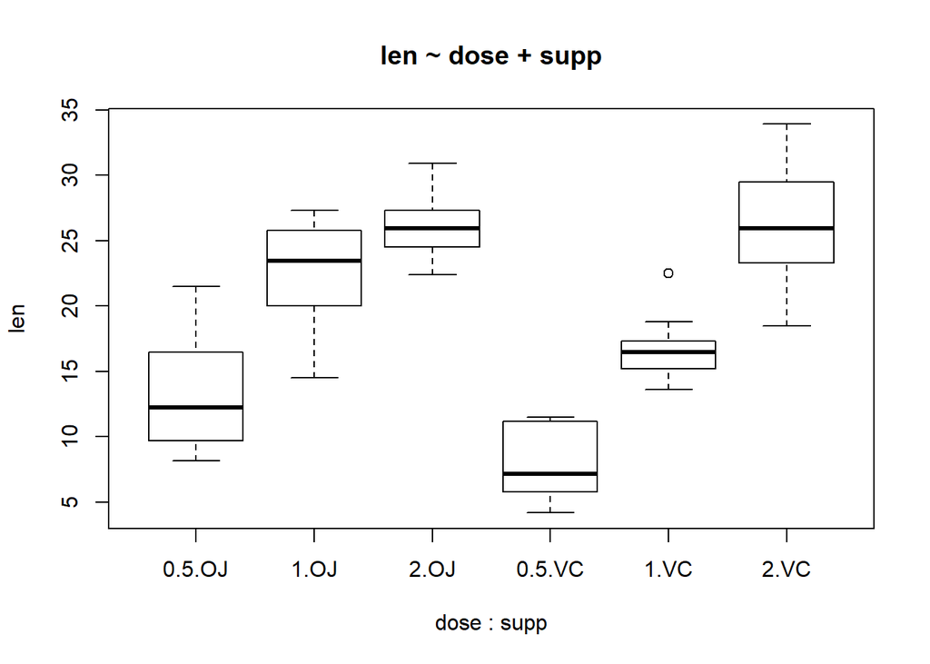

```r
boxplot(len ~ dose + supp, data = ToothGrowth, main="len ~ dose + supp")
```

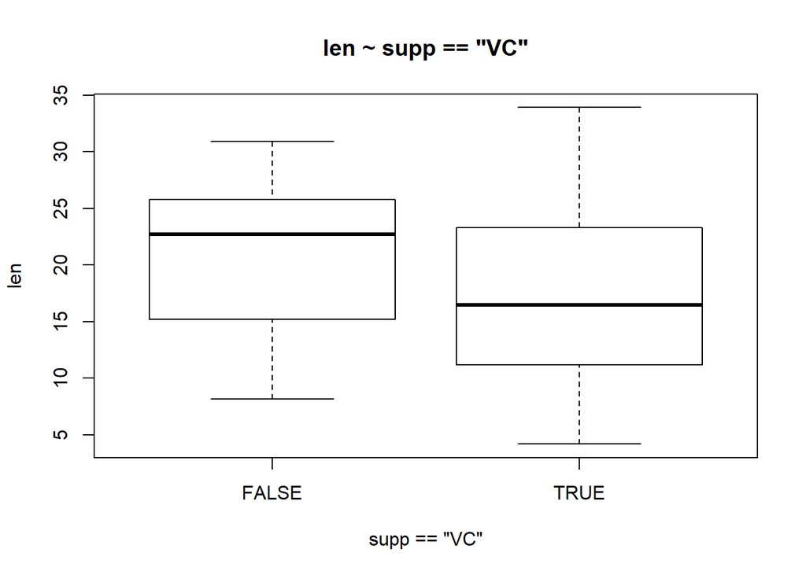

```r
boxplot(len ~ supp == "VC", data = ToothGrowth) #원하는 자료만 선택
title("len ~ supp == \"VC\"")
```

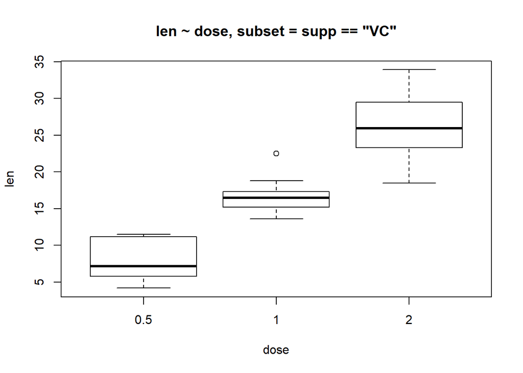

```r
boxplot(len ~ dose, data = ToothGrowth, subset = supp == "VC") # subset 옵션 사용 가능
title("len ~ dose, subset = supp == \"VC\"")
```

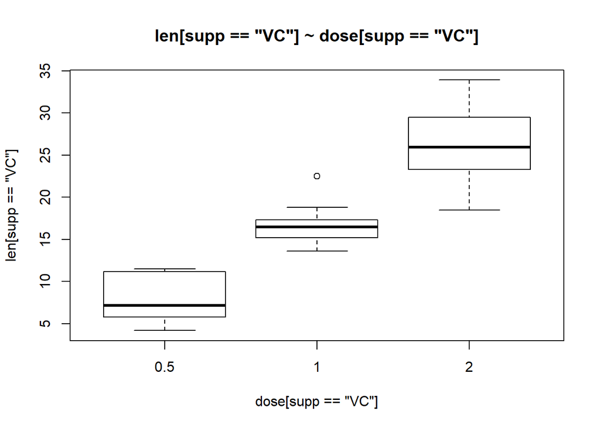

```r
boxplot(len[supp == "VC"] ~ dose[supp == "VC"], data = ToothGrowth)
title("len[supp == \"VC\"] ~ dose[supp == \"VC\"]")
```

### 이상치 표현

- 상자그림을 통해 이상치가 자료에 있는지 알 수 있습니다.
- 이상치 처리하지 않고 상자그림을 그리거나?
- 특정 범위 내의 자료만 상자그림을 그리싶다면…
- range 옵션을 통해 이를 조정할 수 있습니다.

```r
set.seed(3)
z <- round(rnorm(50) * 10)
summary(z)
```

```
##    Min. 1st Qu.  Median    Mean 3rd Qu.    Max.
##  -23.00   -7.00   -1.50   -0.66    7.00   17.00
```

```r
z[50] <- 40       # 50번째 데이터를 40으로 치환하여 이상치를 만듦
summary(z)
```

```
##    Min. 1st Qu.  Median    Mean 3rd Qu.    Max.
##  -23.00   -7.00   -0.50    0.32    7.75   40.00
```

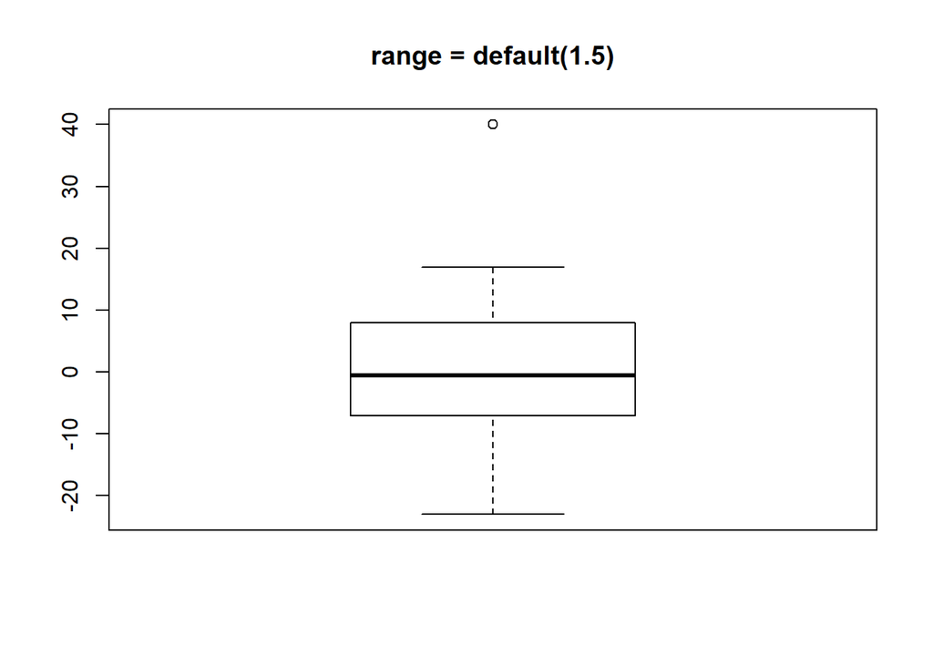

```r
boxplot(z)
title(main="range = default(1.5)")
```

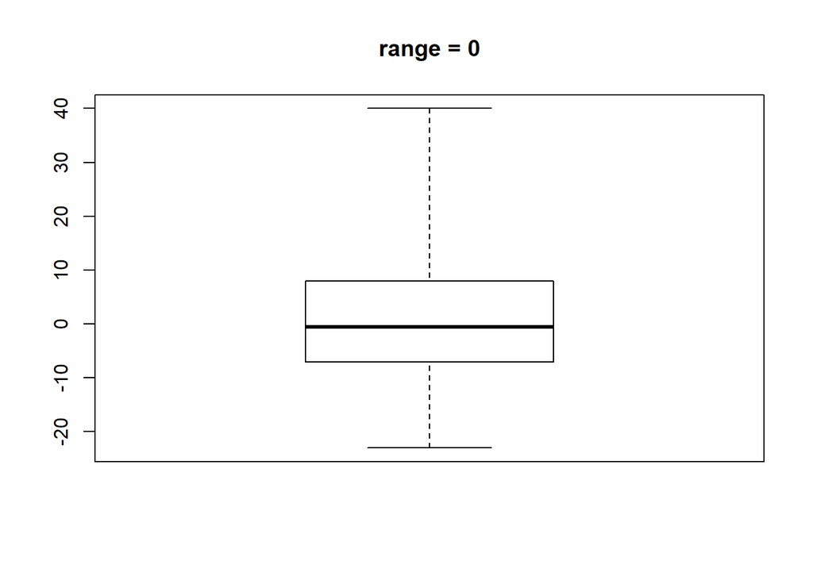

```r
boxplot(z, range = 0) # 이상치 없이 최대 최소 모두 그리기
title(main="range = 0")
```

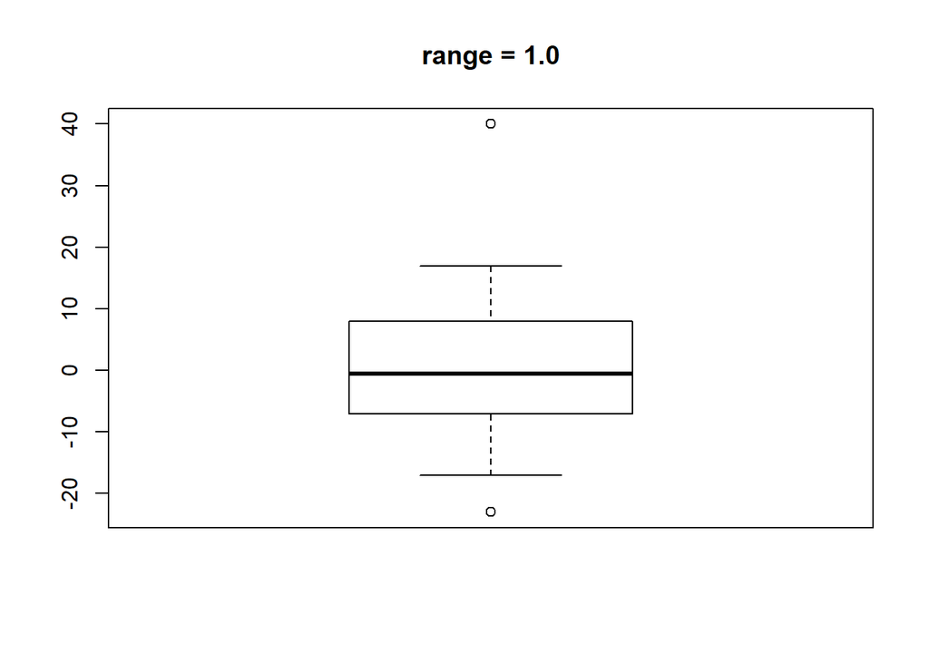

```r
boxplot(z, range = 1.0) # IQR 범위까지 상자 그리기기
title(main="range = 1.0")
```

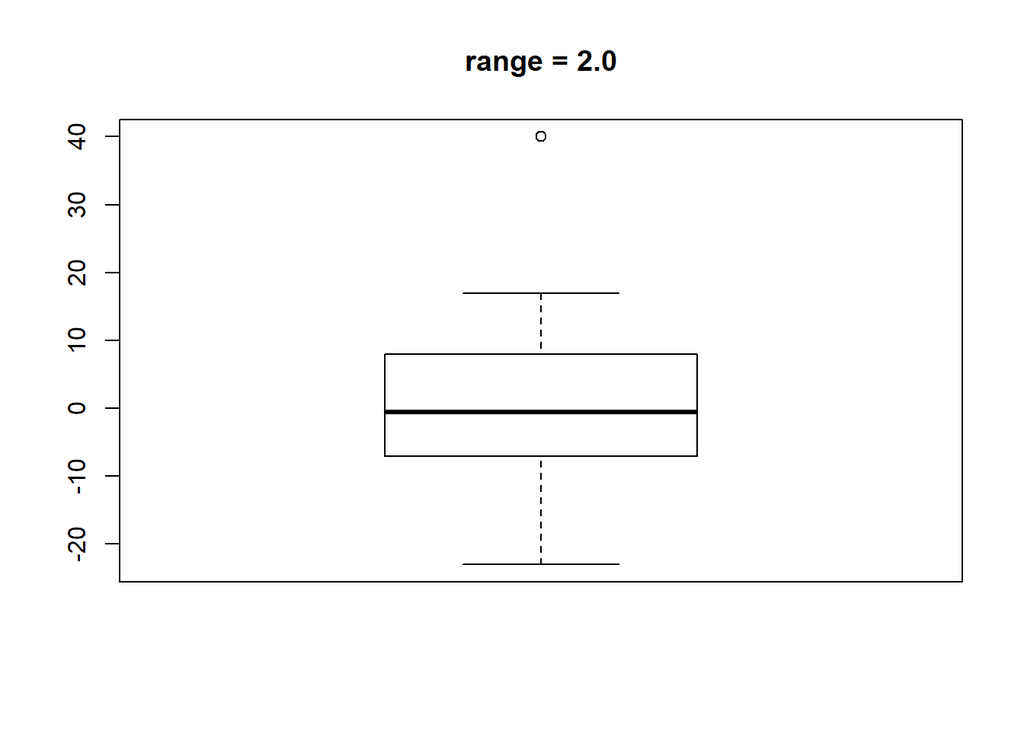

```r
boxplot(z, range = 2.0) # IQR * 2 범위까지 상자 그리기
title(main="range = 2.0")
```

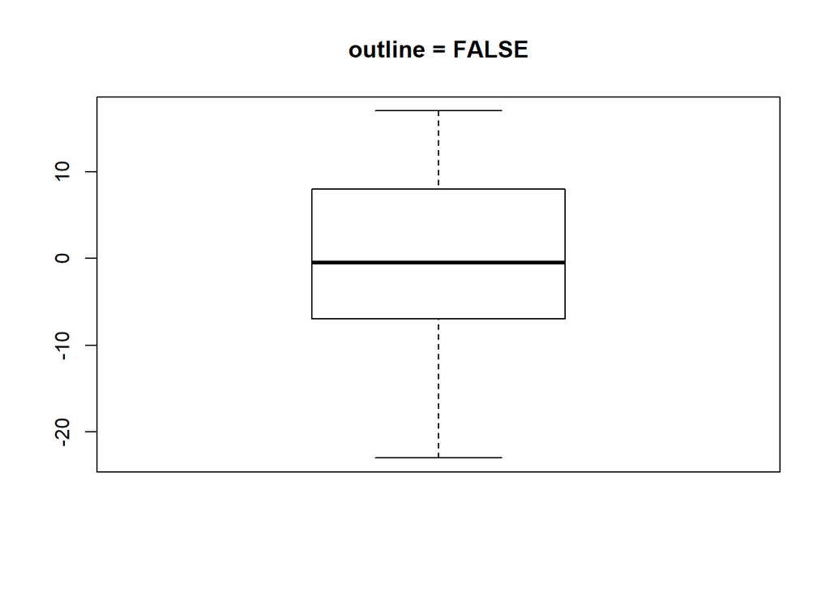

```r
boxplot(z, outline = F, main = "outline = FALSE") # 이상치만 표현하지 않기
```

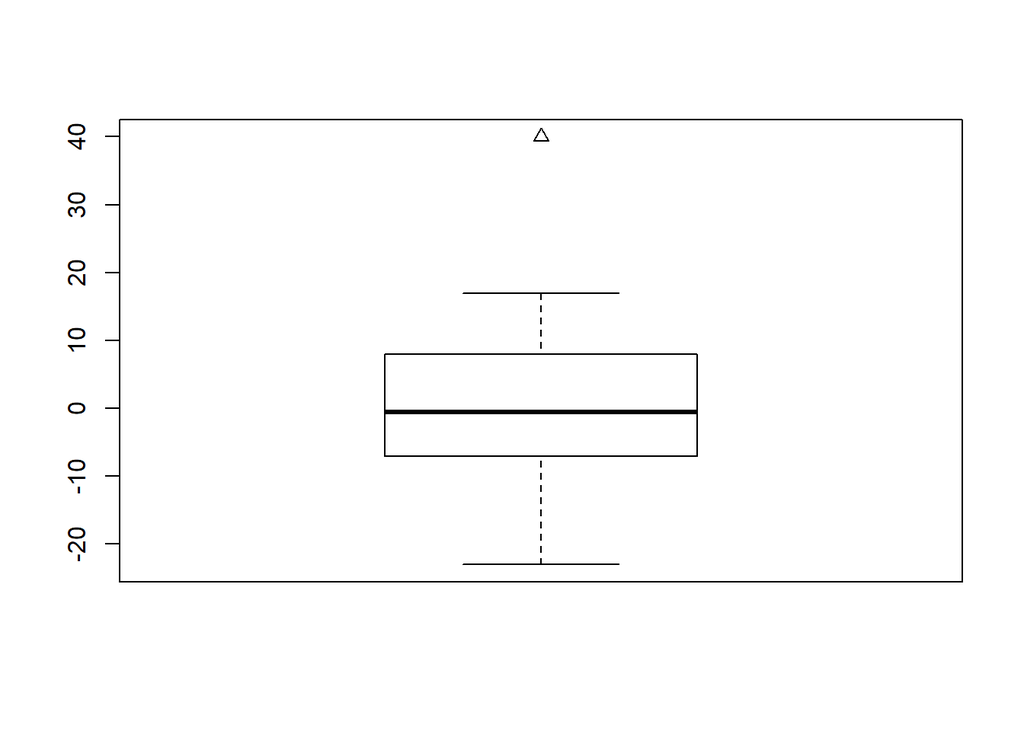

```r
boxplot(z, outpch = 2) # 이상치의 모양 바꾸기
```

### 상자기름의 이름과 폭 조정

- width : 상자그림의 폭을 조정합니다.
- varwidth : 자료의 수에 따라 폭을 조정합니다.
- names : 상자그림 밑에 들어가는 글자를 지정합니다.
- 물론 names함수를 통해 직접 x에 이름을 줄 수 있습니다.

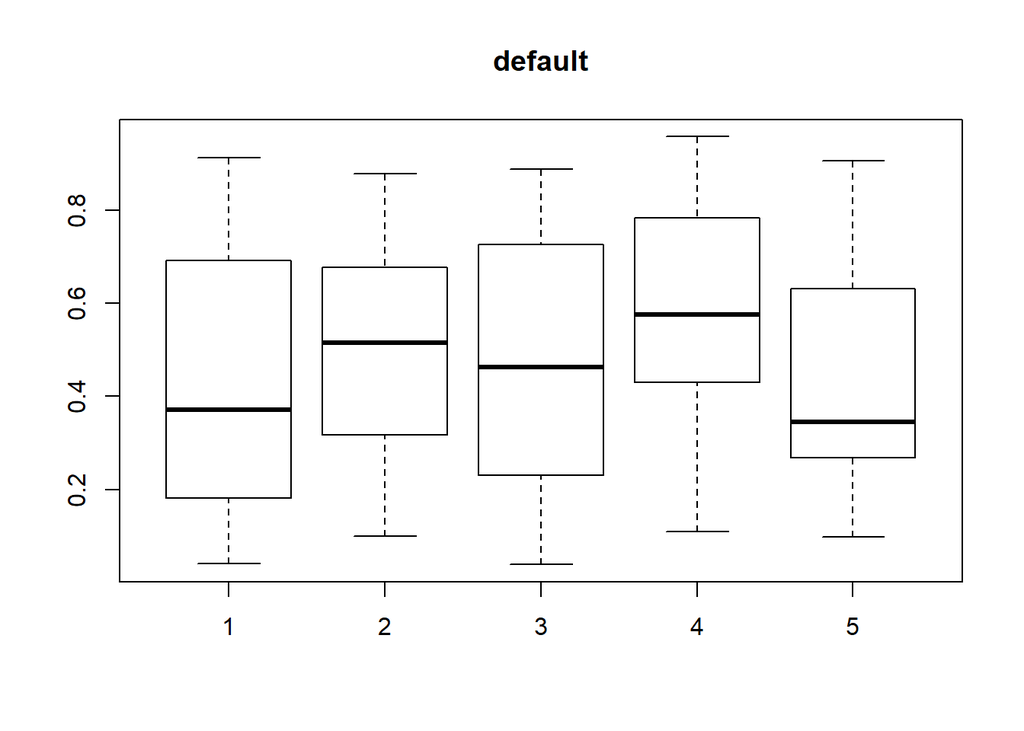

```r
x1 <- runif(20)
x2 <- runif(20)
x3 <- runif(20)
x4 <- runif(20)
x5 <- runif(20)
x <- list(x1, x2, x3, x4, x5)

y1 <- runif(10)
y2 <- runif(40)
y3 <- runif(90)
y4 <- runif(160)
y <- list(y1, y2, y3, y4)

boxplot(x)
title(main = "default")
```

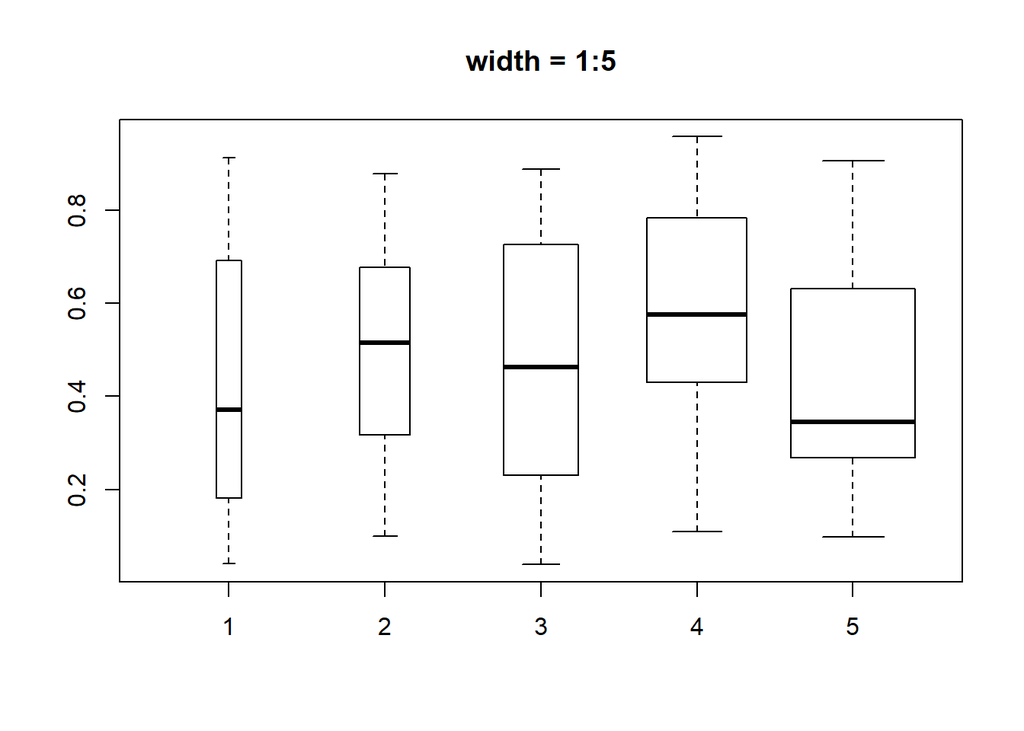

```r
boxplot(x, width = 1:5)
title(main = "width = 1:5")
```

```r
str(y)
```

```
## List of 4
##  $ : num [1:10] 0.731 0.86 0.343 0.493 0.854 ...
##  $ : num [1:40] 0.7285 0.4766 0.5819 0.2071 0.0289 ...
##  $ : num [1:90] 0.223 0.255 0.65 0.617 0.253 ...
##  $ : num [1:160] 0.593 0.282 0.338 0.498 0.594 ...
```

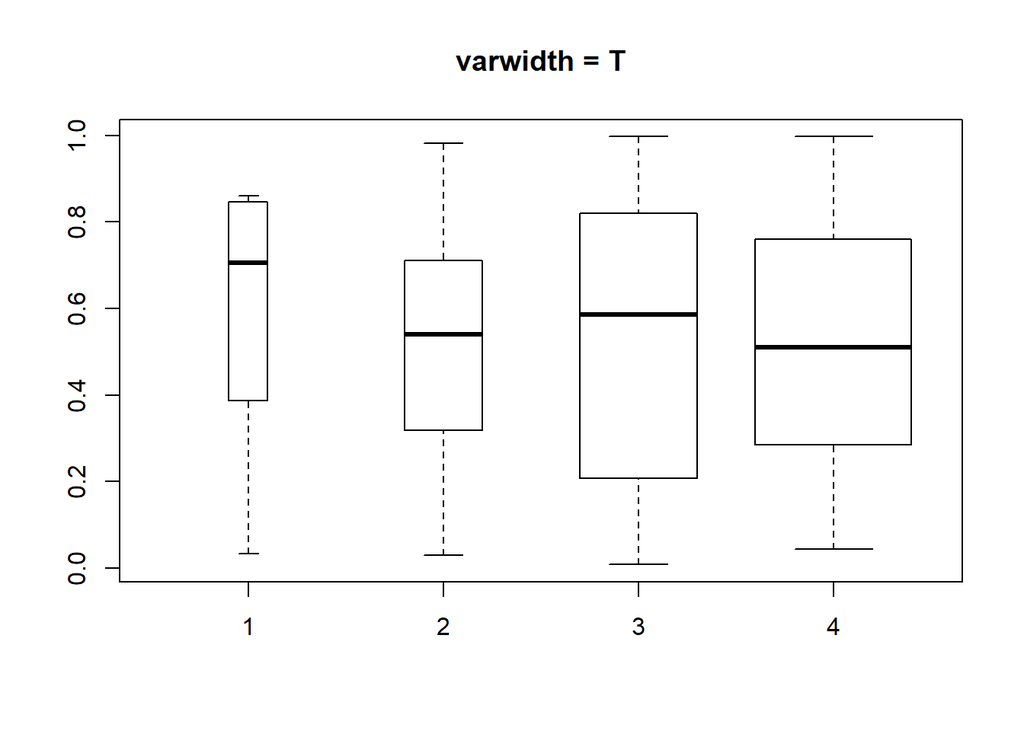

```r
boxplot(y, varwidth = T)
title(main = "varwidth = T")
```

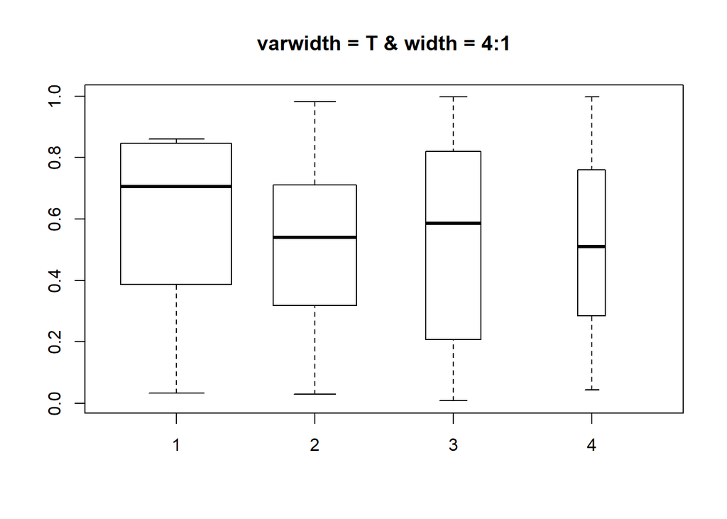

```r
boxplot(y, varwidth = T, width = 4:1)
title(main = "varwidth = T & width = 4:1")
```

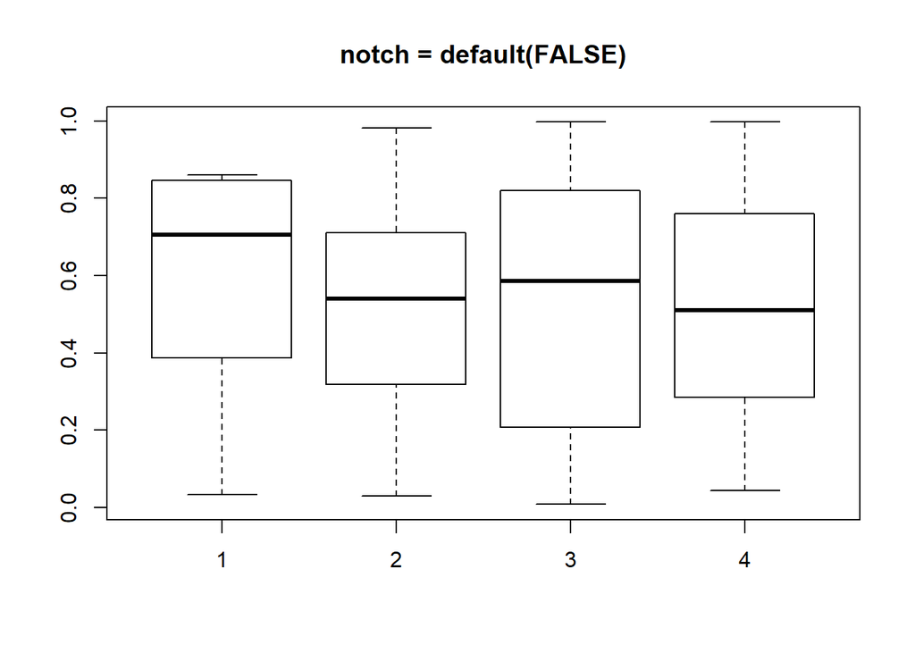

```r
boxplot(y)
title(main = "notch = default(FALSE)")
```

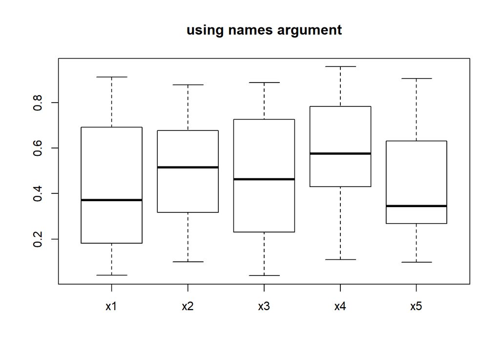

```r
xname <- c("x1", "x2", "x3", "x4", "x5")
boxplot(x, names = xname)
title(main = "using names argument")
```

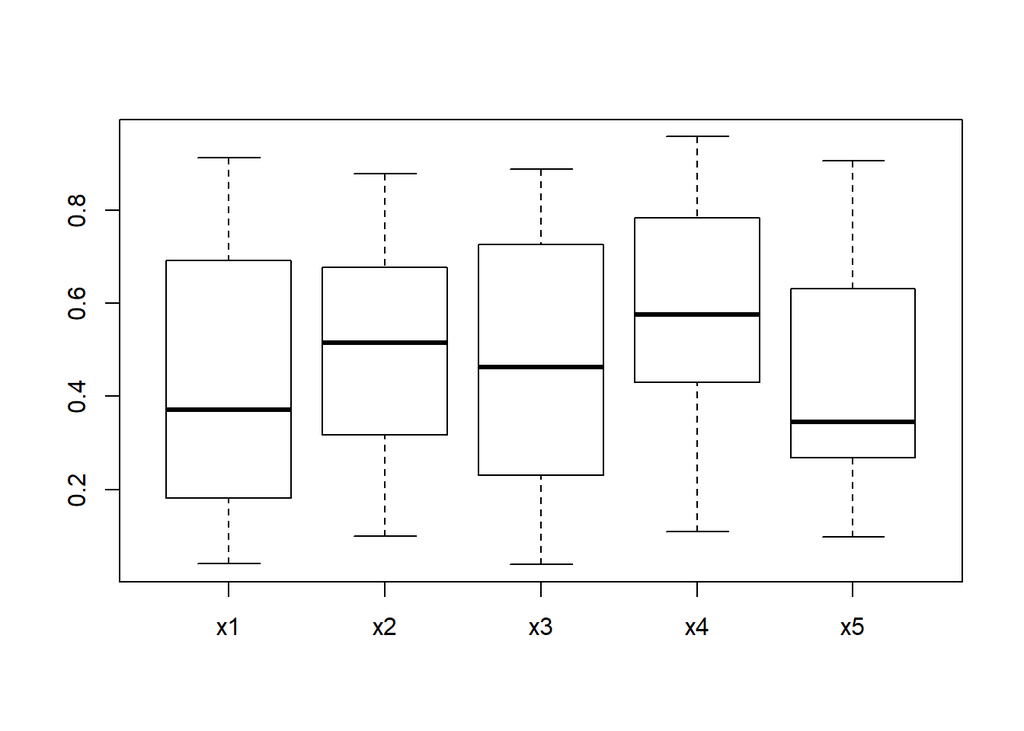

```r
names(x) <- c("x1", "x2", "x3", "x4", "x5")
boxplot(x)
```

- width 대신에 boxwex를 이용하여 상자의 폭을 조정할 수 있습니다. 기본은 0.8입니다.
- staplewex 는 상자그림의 끝에 있는 길이의 폭입니다.

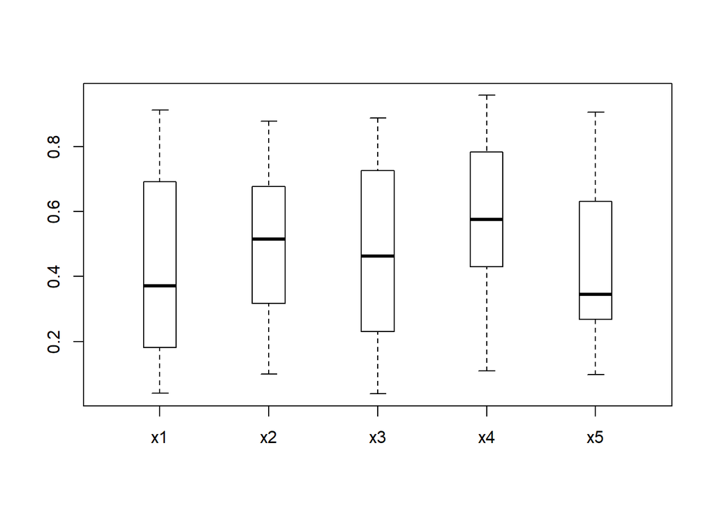

```r
boxplot(x, boxwex = 0.3)
```

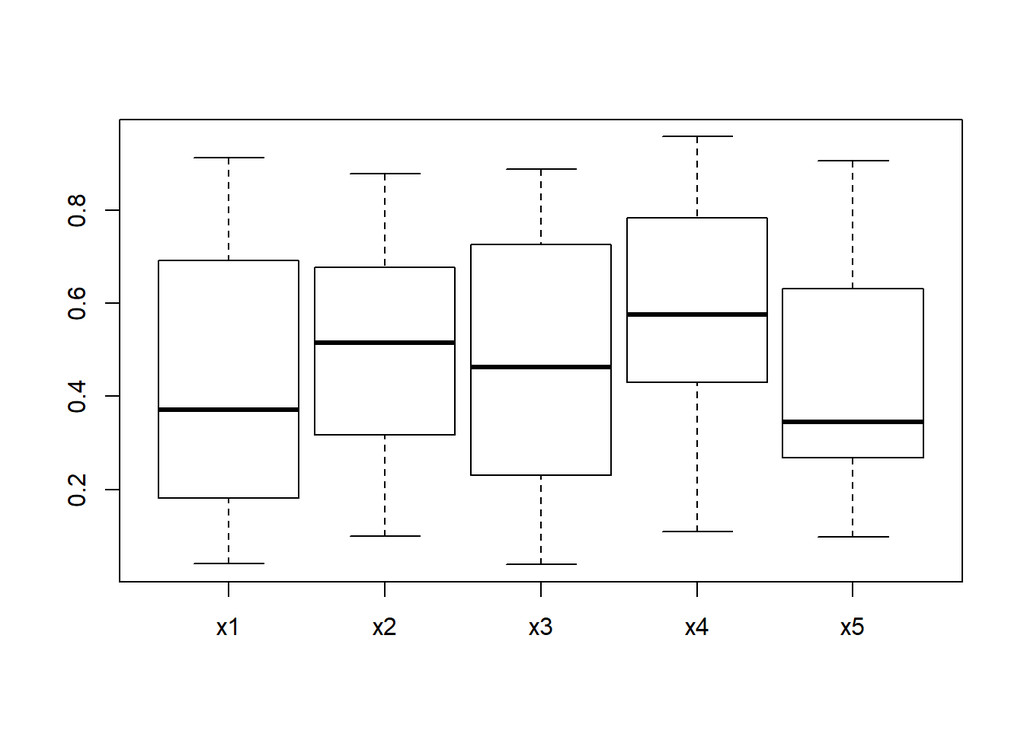

```r
boxplot(x, boxwex = 0.9)
```

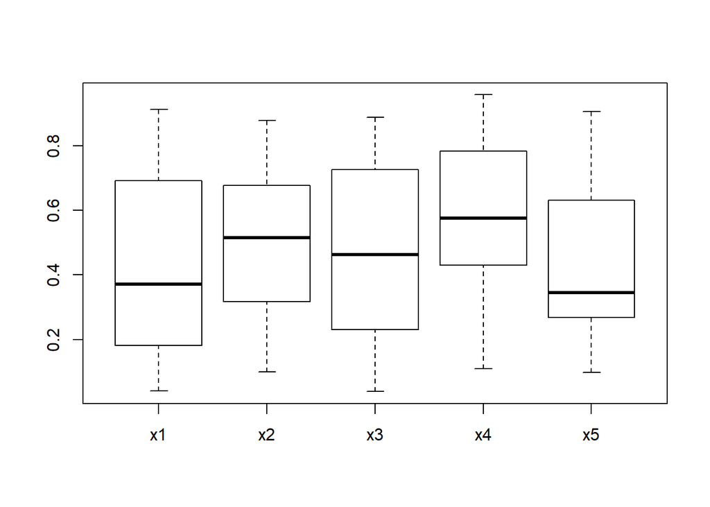

```r
boxplot(x, staplewex = 0.2)
```

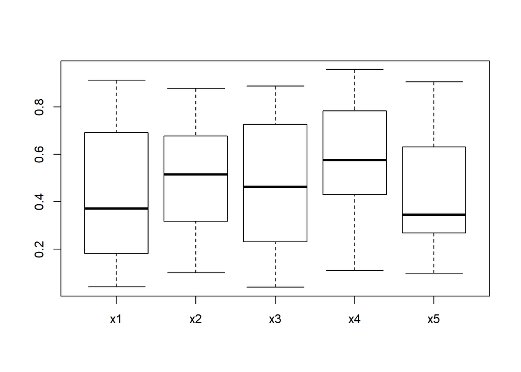

```r
boxplot(x, staplewex = 0.9)
```

### 상자그림 저장

상자그림을 저장하면 상자그림을 그리기 위한 요약값, 자료의 수 등이 저장됩니다.

그리고 기본적으로 상자그림이 그려집니다. 만약 그림 확인이 필요 없다면 plot=FALSE 을 넣으세요.

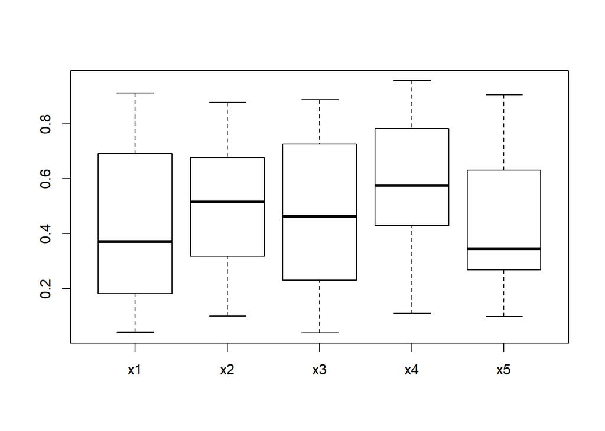

```r
b1<-boxplot(x)
```

```r
b2<-boxplot(x, plot = FALSE)
```

### 그 외의 옵션들

- border : 상자그림을 그리는 선의 색
- horizontal : 수평으로된 상자그림
- at : 상지그림을 원하는 위치에 그리고자 할 경우
- add = TRUE : 기존의 그림에 추가하여 그림을 그립니다.

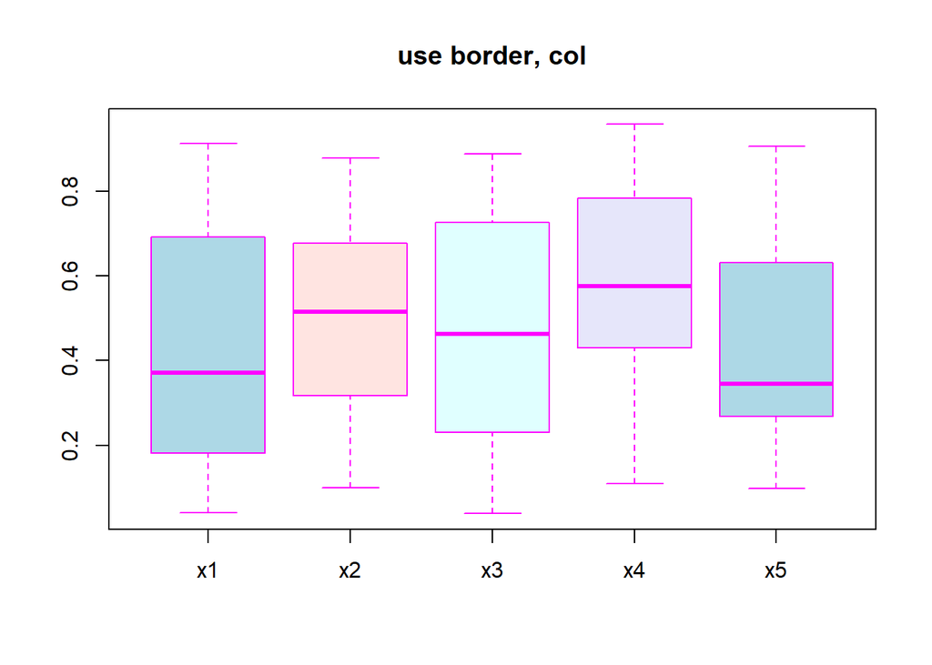

```r
boxplot(x, border = "magenta", col = c("lightblue", "mistyrose", "lightcyan", "lavender"))
title(main = "use border, col")
```

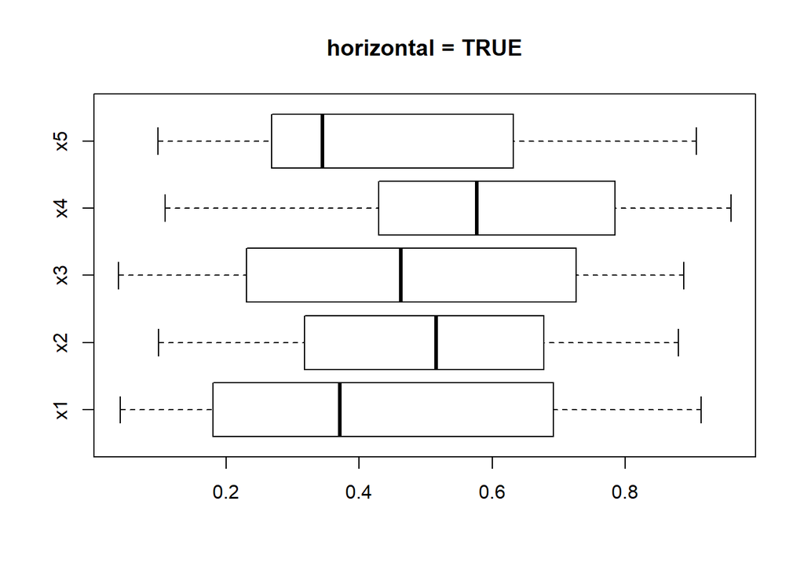

```r
boxplot(x, horizontal = TRUE)
title(main = "horizontal = TRUE")
```

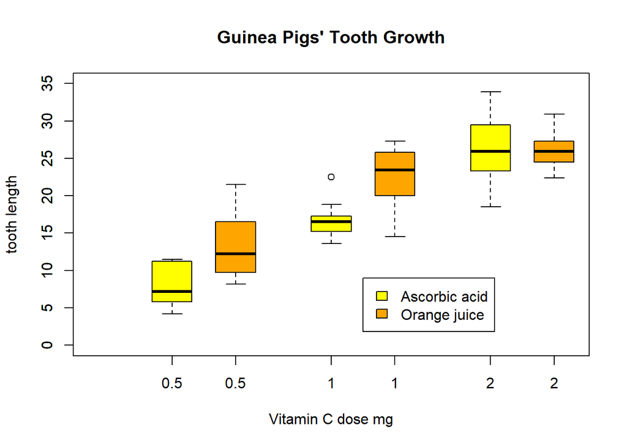

```r
# at을 통해 원하는 위치에 상자그림을 그릴 수 있음
boxplot(len ~ dose, data = ToothGrowth, boxwex = 0.25, at = 1:3 - 0.2,
          subset = supp == "VC", col = "yellow", main = "Guinea Pigs' Tooth Growth",
          xlab = "Vitamin C dose mg", ylab = "tooth length", ylim = c(0, 35))

boxplot(len ~ dose, data = ToothGrowth, add = TRUE, boxwex = 0.25, at = 1:3 + 0.2,
          subset = supp == "OJ", col = "orange")

legend(2, 9, c("Ascorbic acid", "Orange juice"), fill = c("yellow", "orange"))
```